# Step 2 - SGA Dataset Reduction

Anna Ruby

February 1, 2019

## Importing Libraries

```r
rm(list=ls())
library(readxl)
library(tidyverse)
library(doBy)
library(caret)
library(randomForest)
library(data.table)
library(knitr)
library(kableExtra)
library(summarytools)
```

## Loading Data

Note that Prof. Wilhelm’s ident matrix data will be used here, as well as the “tks_logitudinal.Rdata” file used in the creation of my ident data.

```r
load("../Data/tks_longitudinal.Rdata")
load("../Data/stage8_ident.Rdata")
```

## Prepping SGA Data

| **No** | **Variable** | **Stats / Values** | **Freqs (% of Valid)** | **Graph** | **Missing** |
| --- | --- | --- | --- | --- | --- |
| 1 | CHARGEN_NR [integer] | Mean (sd) : 453803.1 (257085.2) min < med < max: 163171 < 681471 < 722691 IQR (CV) : 515320 (0.6) | 242 distinct values |  | 0 (0%) |
| 2 | VORBRAMME [integer] | Mean (sd) : 275.8 (249.6) min < med < max: 22 < 53 < 553 IQR (CV) : 500 (0.9) | 22 distinct values |  | 0 (0%) |
| 3 | VORG_HAUPTAGGREGAT [factor] | 1. BRFL01 2. BRSG01 | 249384 ( 28.2% ) 634438 ( 71.8% ) |  | 0 (0%) |
| 4 | STRANGNUMMER [integer] | Min : 1 Mean : 1.5 Max : 2 | 1 : 458785 ( 51.9% ) 2 : 425037 ( 48.1% ) |  | 0 (0%) |
| 5 | SEQBEGINN [factor] | 1. 2016-10-24 17:54:20.00000 2. 2016-10-26 08:16:23.00000 3. 2016-10-27 04:36:30.00000 4. 2016-10-28 20:39:39.00000 5. 2016-11-01 08:13:19.00000 6. 2016-11-23 11:36:21.00000 7. 2016-11-24 22:42:28.000… | 2651 ( 0.3% ) 2050 ( 0.2% ) 1248 ( 0.1% ) 3439 ( 0.4% ) 15100 ( 1.7% ) 1167 ( 0.1% ) 1159 ( 0.1% ) 13175 ( 1.5% ) 2220 ( 0.3% ) 2308 ( 0.3% ) 839305 ( 95.0% ) |  | 0 (0%) |
| 6 | ZEITSTEMPEL [factor] | 1. 2016-10-24 19:04:00.00000 2. 2016-10-24 19:04:01.00000 3. 2016-10-24 19:04:02.00000 4. 2016-10-24 19:04:03.00000 5. 2016-10-24 19:04:04.00000 6. 2016-10-24 19:04:05.00000 7. 2016-10-24 19:04:06.000… | 2 ( 0.0% ) 2 ( 0.0% ) 2 ( 0.0% ) 2 ( 0.0% ) 2 ( 0.0% ) 2 ( 0.0% ) 2 ( 0.0% ) 2 ( 0.0% ) 2 ( 0.0% ) 2 ( 0.0% ) 883802 ( 100.0% ) |  | 0 (0%) |
| 7 | SCHMELZE [integer] | Mean (sd) : 453803.1 (257085.2) min < med < max: 163171 < 681471 < 722691 IQR (CV) : 515320 (0.6) | 242 distinct values |  | 0 (0%) |
| 8 | BRAMMENNUMMER [integer] | Mean (sd) : 273.2 (249.6) min < med < max: 20 < 50 < 550 IQR (CV) : 500 (0.9) | 11 distinct values |  | 0 (0%) |
| 9 | LFD [integer] | Mean (sd) : 12.1 (5) min < med < max: 3 < 12 < 22 IQR (CV) : 8 (0.4) | 20 distinct values |  | 0 (0%) |
| 10 | QUALITAET [factor] | 1. 28VA1 | 883822 ( 100.0% ) |  | 0 (0%) |
| 11 | STRANGLAENGE [numeric] | Mean (sd) : 118.3 (51.9) min < med < max: 18.5 < 114.1 < 227.1 IQR (CV) : 88.6 (0.4) | 153894 distinct values |  | 0 (0%) |
| 12 | RIEGELLAENGE [numeric] | Mean (sd) : 5.5 (3.2) min < med < max: 0 < 5.4 < 11.7 IQR (CV) : 5.4 (0.6) | 11645 distinct values |  | 0 (0%) |
| 13 | TO_FS_SSL [numeric] | Mean (sd) : 182.8 (34.7) min < med < max: 0 < 185.2 < 800 IQR (CV) : 18.4 (0.2) | 3496 distinct values |  | 0 (0%) |
| 14 | TO_FS_M [numeric] | Mean (sd) : 182.9 (15.7) min < med < max: 133.4 < 181.8 < 232.6 IQR (CV) : 21.4 (0.1) | 983 distinct values |  | 0 (0%) |
| 15 | TO_FS_SSR [numeric] | Mean (sd) : 188.3 (13.3) min < med < max: 142.4 < 189.1 < 226.4 IQR (CV) : 17 (0.1) | 835 distinct values |  | 0 (0%) |
| 16 | TO_SSR_FS [numeric] | Mean (sd) : 199.8 (15.6) min < med < max: 144.5 < 201.3 < 242.8 IQR (CV) : 18.2 (0.1) | 973 distinct values |  | 0 (0%) |
| 17 | TO_SSR_LS [numeric] | Mean (sd) : 195.8 (14.8) min < med < max: 140.3 < 197.6 < 237.2 IQR (CV) : 17.1 (0.1) | 970 distinct values |  | 0 (0%) |
| 18 | TO_LS_SSR [numeric] | Mean (sd) : 192.2 (12.9) min < med < max: 143.7 < 193.9 < 229.6 IQR (CV) : 16.9 (0.1) | 851 distinct values |  | 0 (0%) |
| 19 | TO_LS_M [numeric] | Mean (sd) : 183.7 (13.8) min < med < max: 136.5 < 186.1 < 226.8 IQR (CV) : 17.1 (0.1) | 874 distinct values |  | 0 (0%) |
| 20 | TO_LS_SSL [numeric] | Mean (sd) : 193.2 (12.6) min < med < max: 149.3 < 195 < 229.1 IQR (CV) : 16.7 (0.1) | 796 distinct values |  | 0 (0%) |
| 21 | TO_SSL_LS [numeric] | Mean (sd) : 198.7 (15.3) min < med < max: 137.7 < 200.2 < 243.8 IQR (CV) : 16.7 (0.1) | 900 distinct values |  | 0 (0%) |
| 22 | TO_SSL_FS [numeric] | Mean (sd) : 201.8 (15.3) min < med < max: 147.6 < 202.8 < 242.9 IQR (CV) : 16 (0.1) | 923 distinct values |  | 0 (0%) |
| 23 | TM_FS_SSL [numeric] | Mean (sd) : 125.5 (10.2) min < med < max: 93.1 < 125.3 < 161.1 IQR (CV) : 15.2 (0.1) | 675 distinct values |  | 0 (0%) |
| 24 | TM_FS_M [numeric] | Mean (sd) : 127.2 (11.4) min < med < max: 90.1 < 128.1 < 159.4 IQR (CV) : 16.1 (0.1) | 667 distinct values |  | 0 (0%) |
| 25 | TM_FS_SSR [numeric] | Mean (sd) : 126.9 (10.8) min < med < max: 95.2 < 127.5 < 162.2 IQR (CV) : 16.1 (0.1) | 661 distinct values |  | 0 (0%) |
| 26 | TM_SSR_FS [numeric] | Mean (sd) : 134.7 (10) min < med < max: 103.1 < 134.5 < 177.4 IQR (CV) : 13.5 (0.1) | 726 distinct values |  | 0 (0%) |
| 27 | TM_SSR_LS [numeric] | Mean (sd) : 128.2 (8.7) min < med < max: 101 < 128.3 < 163.6 IQR (CV) : 12 (0.1) | 623 distinct values |  | 0 (0%) |
| 28 | TM_LS_SSR [numeric] | Mean (sd) : 131.2 (10.7) min < med < max: 99.7 < 131.2 < 169.3 IQR (CV) : 15.1 (0.1) | 692 distinct values |  | 0 (0%) |
| 29 | TM_LS_M [numeric] | Mean (sd) : 124.2 (10) min < med < max: 77 < 124.9 < 153.2 IQR (CV) : 13.5 (0.1) | 691 distinct values |  | 0 (0%) |
| 30 | TM_LS_SSL [numeric] | Mean (sd) : 130.6 (9.8) min < med < max: 101 < 130.4 < 164.1 IQR (CV) : 14.7 (0.1) | 624 distinct values |  | 0 (0%) |

[output cut: 54 more lines]

Generated by summarytools 0.9.4 ([R](https://www.r-project.org/) version 3.6.1)  
2019-11-18

By looking at the summary statistics one can immeadiately see three odd variables: “QUALITAET”, “GSR_AUTO”, and “VG_Min”. Qualitaet appears to be a categorical variable with only one level while both GSR_Auto and VG_Min seem to be constant. We also have a couple of time dependant variables, which are to be removed. As both GSR_Auto and VG_Min are both completely constant, we will drop them below as well.

### Removing Variables

First, the two time dependant, constant, and redundant variables are dropped. These are, respectively,

- “SEQBEGINN”
- “ZEITSTEMPEL”
- “VG_MIN”
- “GSR_AUTO”
- “QUALITAET”
- “SCHMELZE”
- “BRAMMENNUMMER”
- “LFD”
- “STRANGLAENGE”

```r
#dropping variables

data_SGA <- dplyr::select(SGA_Prozessdaten_Durchsatz, -c("SEQBEGINN", "ZEITSTEMPEL", "VG_MIN", "GSR_AUTO", "QUALITAET", "SCHMELZE", "BRAMMENNUMMER", "LFD", "STRANGLAENGE"))
```

Then, variables are removed at the request of Dr. Eberle. *(Email on 27.8.18)*

```r
#drop any TSCHL var
data_SGA <- data_SGA %>%
  dplyr::select(-starts_with("TSCHL"))
```

Finally, variables are removed as per S. Karrasch.

```r
#dropping variables at the instruction of S. Karrasch
data_SGA <- data_SGA %>%
  dplyr::select(-SCHIEBERFAHRT, -DAUERTEMPERATUR, -GEWICHT)
```

### Data Manipulation

```r
#Changing TUNDISH_POSITION from int to numeric
data_SGA <- data_SGA %>%
  dplyr::mutate(
    TUNDISH_POSITION = as.numeric(TUNDISH_POSITION)
  )

#Creating variable lists acorrding to type
df <- data_SGA
var.index <- c("CHARGEN_NR", "VORBRAMME")
var.list <- colnames(df)
var.int <- colnames(df[,sapply(df,is.integer)])
var.factor <- colnames(df[,sapply(df,is.factor)])
var.num <- colnames(df[,sapply(df,is.numeric)])

#split above DF acording to type
df_int <- df %>%
  dplyr::select(var.index,var.int)
df_factor <- df %>%
  dplyr::select(var.index,var.factor)
df_num <- df %>%
  dplyr::select(var.num, -var.int)
var_num <- colnames(df_num)
```

```r
#Convert SGA to long format - check data availability & missing patterns
data_SGA_long <- data_SGA %>%
  tidyr::gather(key=length_attr, value=measurement, -c(CHARGEN_NR, VORBRAMME, RIEGELLAENGE))
```

#### Computing descriptives

Variable Descriptives

| length_attr | count | unique | na | N |
| --- | --- | --- | --- | --- |
| ARGON_DRUCK_ST | 883822 | 95 | 0 | 883822 |
| ARGON_DURCHFL_DUSCH | 883822 | 1439 | 0 | 883822 |
| ARGON_DURCHFL_ST | 883822 | 409 | 0 | 883822 |
| DT_FS | 883822 | 345 | 0 | 883822 |
| DT_LS | 883822 | 359 | 0 | 883822 |
| DT_SSL | 883822 | 296 | 0 | 883822 |
| DT_SSR | 883822 | 254 | 0 | 883822 |
| FUELLSTAND | 883822 | 11 | 0 | 883822 |
| FUELLSTAND_VHUZ | 883822 | 11 | 0 | 883822 |
| KONI_LINKS | 883822 | 151 | 0 | 883822 |
| KONI_RECHTS | 883822 | 171 | 0 | 883822 |
| NETTO_PFANNENINHALT | 883822 | 3498 | 0 | 883822 |
| PLATTENDICKE_SSL | 883822 | 18 | 0 | 883822 |
| PLATTENDICKE_SSR | 883822 | 18 | 0 | 883822 |
| SCHLACKELIMIT | 883822 | 2 | 0 | 883822 |
| SCHLACKESIGNAL | 883822 | 581 | 0 | 883822 |
| SP_SIGNAL | 883822 | 590 | 0 | 883822 |
| SPI_ALARMLIMIT | 883822 | 2 | 0 | 883822 |
| SPI_SIGNAL | 883822 | 99 | 0 | 883822 |
| STOPFENSTELLUNG | 883822 | 28 | 0 | 883822 |
| STRANGBREITE | 883822 | 126 | 0 | 883822 |
| STRANGNUMMER | 883822 | 2 | 0 | 883822 |
| TLEV | 883822 | 2 | 0 | 883822 |
| TM_FS_M | 883822 | 667 | 0 | 883822 |
| TM_FS_SSL | 883822 | 675 | 0 | 883822 |
| TM_FS_SSR | 883822 | 661 | 0 | 883822 |
| TM_LS_M | 883822 | 691 | 0 | 883822 |
| TM_LS_SSL | 883822 | 624 | 0 | 883822 |
| TM_LS_SSR | 883822 | 692 | 0 | 883822 |
| TM_SSL_FS | 883822 | 742 | 0 | 883822 |
| TM_SSL_LS | 883822 | 612 | 0 | 883822 |
| TM_SSR_FS | 883822 | 726 | 0 | 883822 |
| TM_SSR_LS | 883822 | 623 | 0 | 883822 |
| TO_FS_M | 883822 | 983 | 0 | 883822 |
| TO_FS_SSL | 883822 | 3496 | 0 | 883822 |
| TO_FS_SSR | 883822 | 835 | 0 | 883822 |
| TO_LS_M | 883822 | 874 | 0 | 883822 |
| TO_LS_SSL | 883822 | 796 | 0 | 883822 |
| TO_LS_SSR | 883822 | 851 | 0 | 883822 |
| TO_SSL_FS | 883822 | 923 | 0 | 883822 |
| TO_SSL_LS | 883822 | 900 | 0 | 883822 |
| TO_SSR_FS | 883822 | 973 | 0 | 883822 |
| TO_SSR_LS | 883822 | 970 | 0 | 883822 |
| TU_FS_M | 883822 | 582 | 0 | 883822 |
| TU_FS_SSL | 883822 | 562 | 0 | 883822 |
| TU_FS_SSR | 883822 | 615 | 0 | 883822 |
| TU_LS_M | 883822 | 708 | 0 | 883822 |
| TU_LS_SSL | 883822 | 626 | 0 | 883822 |
| TU_LS_SSR | 883822 | 639 | 0 | 883822 |
| TU_SSL_FS | 883822 | 669 | 0 | 883822 |
| TU_SSL_LS | 883822 | 584 | 0 | 883822 |
| TU_SSR_FS | 883822 | 597 | 0 | 883822 |
| TU_SSR_LS | 883822 | 634 | 0 | 883822 |
| TUNDISH_POSITION | 883822 | 37 | 0 | 883822 |
| VERTEILERFUELLSTAND | 883822 | 220 | 0 | 883822 |
| VG | 883822 | 357 | 0 | 883822 |
| VORG_HAUPTAGGREGAT | 883822 | 2 | 0 | 883822 |
| WASSER_FS | 883822 | 161 | 0 | 883822 |
| WASSER_LS | 883822 | 146 | 0 | 883822 |
| WASSER_SSL | 883822 | 34 | 0 | 883822 |
| WASSER_SSR | 883822 | 46 | 0 | 883822 |

Using the above table we can see that there are no missings in the data.

### Reviewing Variable Distributions

#### Binary Variables

```r
#Checking dist of binary vars
var.SGA.bin <- data_SGA_desc%>%
  dplyr::filter(unique == 2) %>%
  dplyr::select(length_attr) %>%
  unlist()

data_SGA_bin_long <- data_SGA_long %>%
  dplyr::filter(length_attr %in% var.SGA.bin)
```

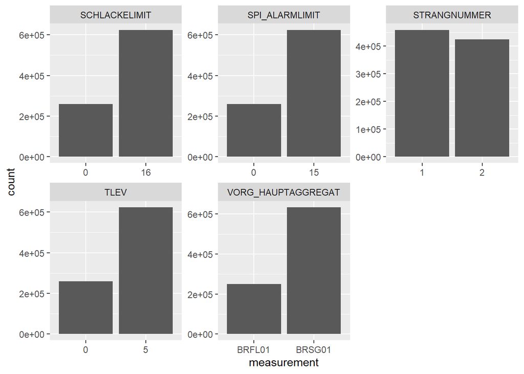

Three variables here have the one of the binary options set to zero. As this is not matched by an expected 1, it is possible that these are actually masked missing values, although this cannot be confirmed here.

#### Numeric Variables - 1–16

```r
#Checking dist of integer variables
#Checking them in groups, as there are so many variables
data_SGA_num_long <- data_SGA_long %>%
  dplyr::filter(length_attr %in% var_num[1:16]) %>%
  dplyr::mutate(
    measurement = as.numeric(measurement)
  )
```

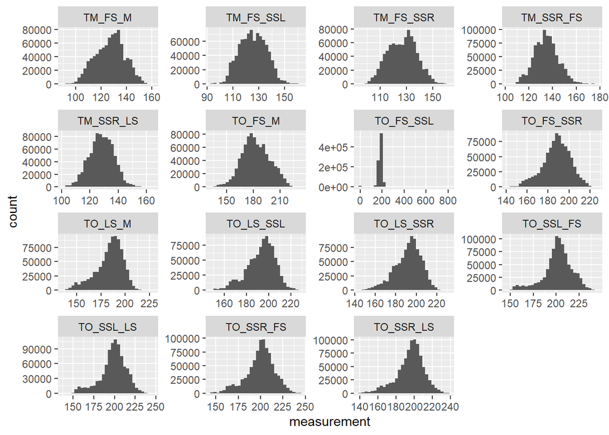

The first variable in var_num is “RIEGELLAENGE”, which has been dropped from our working data, so it does not show a histogram. Although some numeric variables are presenting with skewing, the majority of these seem to be *generally* following some normal distribution. This notably exculdes TO_FS_SSL, which has one high tight spike just below 200 and a handful of 0 values, which may be masked missings.

#### Numeric Variables - 17–32

```r
data_SGA_num_long <- data_SGA_long %>%
  dplyr::filter(length_attr %in% var_num[17:32]) %>%
  dplyr::mutate(
    measurement = as.numeric(measurement)
  )
```

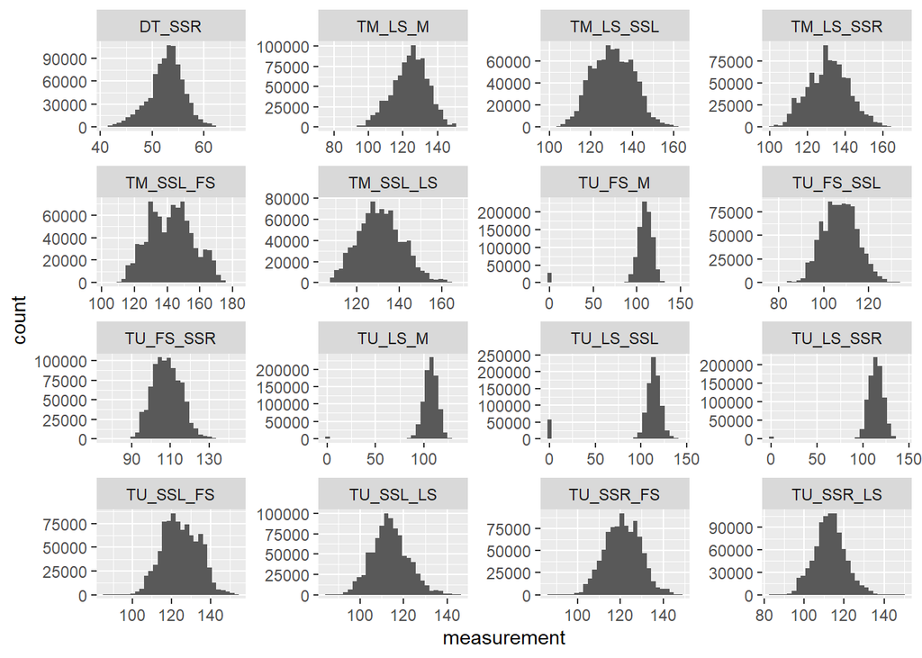

There is one notable bi-modal distribution amoungst this set, but overall, with few exceptions, these also seem to be following generally normal distributions. Again, with regard to exceptions, we see two variables, TU_FS_M & TU_LS_SSL, which have high tight spikes and, seperately, notable amoutns of 0 values. These may, again, be masked missing values. Overall, we see 4 variables that experience high and narrow behaviors,

- TU_FS_M
- TU_LS_M
- TU_LS_SSL
- TU_LS_SSR

#### Numeric Variables - 33–48

```r
data_SGA_num_long <- data_SGA_long %>%
  dplyr::filter(length_attr %in% var_num[33:48]) %>%
  dplyr::mutate(
    measurement = as.numeric(measurement)
  )
```

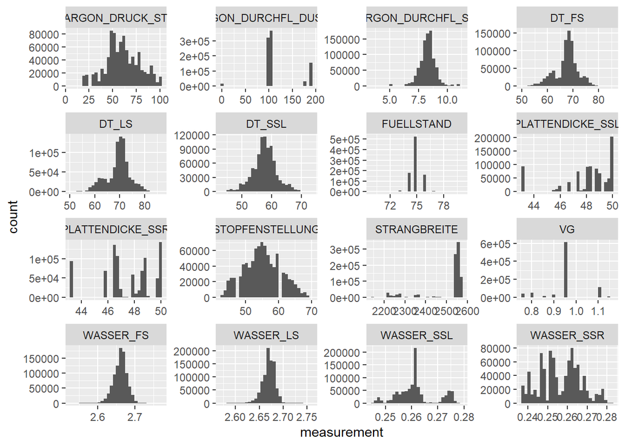

Distributions seen here are markedly more irregular than those seen earlier. STOPFENSTELLUNG has two notable gaps in an otherwise normal seeming distribution.

```r
data_SGA_num_long <- data_SGA_long %>%
  dplyr::filter(length_attr %in% var_num[49:60]) %>%
  dplyr::mutate(
    measurement = as.numeric(measurement)
  )
```

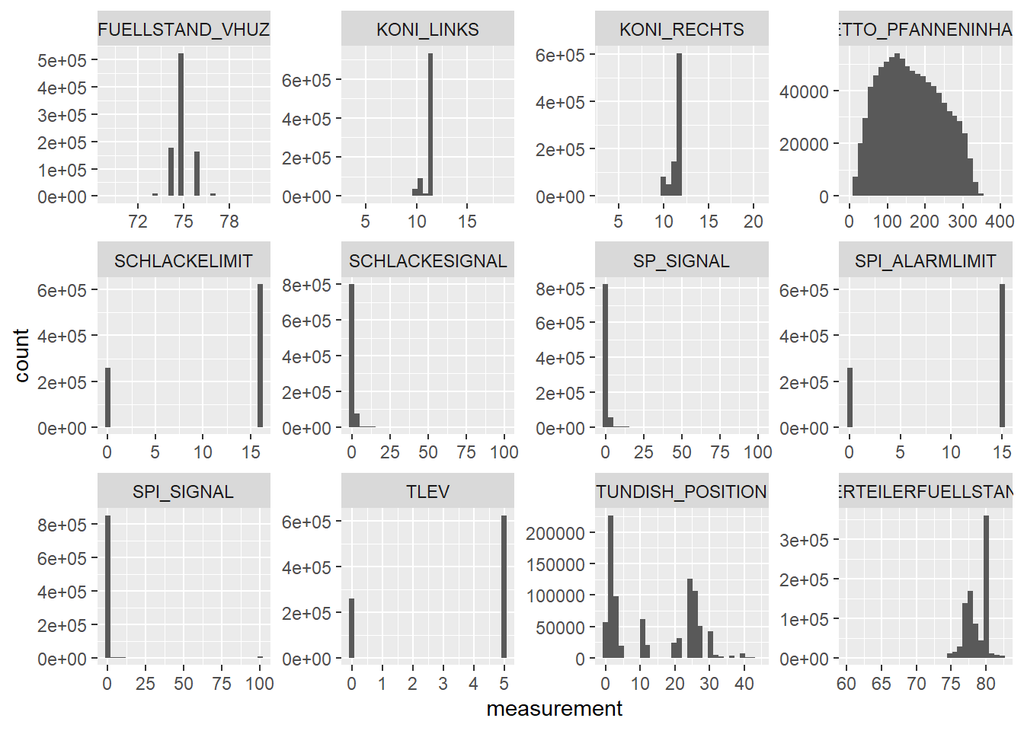

Note that GSR_AUTO has been dropped from our data, and therefore does not produce a histogram. Almost all variables here are presenting with abnormal distributions, and many appear, at a glance, to have a very high number of missing values, such as SPI_Signal. Many of these may be flag variables, although that cannot be conclusively determined here.

#### Computing Descriptives

Numeric Variable Descriptives

| length_attr | count | mean | sd | min | max | unique | na | N |
| --- | --- | --- | --- | --- | --- | --- | --- | --- |
| ARGON_DRUCK_ST | 883822 | 60.3870101 | 17.9292275 | 6.000 | 100.000 | 95 | 0 | 883822 |
| ARGON_DURCHFL_DUSCH | 883822 | 117.4250446 | 38.3152685 | 0.500 | 190.000 | 1439 | 0 | 883822 |
| ARGON_DURCHFL_ST | 883822 | 8.2852902 | 0.6953807 | 3.400 | 11.160 | 409 | 0 | 883822 |
| DT_FS | 883822 | 67.5411042 | 4.4824133 | 50.300 | 85.100 | 345 | 0 | 883822 |
| DT_LS | 883822 | 69.4697668 | 4.7174074 | 50.200 | 86.000 | 359 | 0 | 883822 |
| DT_SSL | 883822 | 57.6426911 | 3.9680557 | 43.100 | 73.000 | 296 | 0 | 883822 |
| DT_SSR | 883822 | 52.7452440 | 3.3532022 | 40.700 | 66.000 | 254 | 0 | 883822 |
| FUELLSTAND | 883822 | 74.9771311 | 0.6903398 | 70.000 | 80.000 | 11 | 0 | 883822 |
| FUELLSTAND_VHUZ | 883822 | 74.9771345 | 0.6903391 | 70.000 | 80.000 | 11 | 0 | 883822 |
| KONI_LINKS | 883822 | 11.3226428 | 0.5775805 | 3.700 | 18.700 | 151 | 0 | 883822 |
| KONI_RECHTS | 883822 | 11.3323759 | 0.5911630 | 3.700 | 20.700 | 171 | 0 | 883822 |
| NETTO_PFANNENINHALT | 883822 | 163.6542687 | 79.8429325 | 0.000 | 404.100 | 3498 | 0 | 883822 |
| PLATTENDICKE_SSL | 883822 | 48.0935047 | 2.0160597 | 43.200 | 50.000 | 18 | 0 | 883822 |
| PLATTENDICKE_SSR | 883822 | 47.5085478 | 1.9801972 | 43.290 | 50.000 | 18 | 0 | 883822 |
| SCHLACKELIMIT | 883822 | 11.2933871 | 7.2906558 | 0.000 | 16.000 | 2 | 0 | 883822 |
| SCHLACKESIGNAL | 883822 | 0.9860209 | 3.1057664 | 0.000 | 100.000 | 581 | 0 | 883822 |
| SP_SIGNAL | 883822 | 1.0499665 | 3.1368693 | 0.000 | 100.000 | 590 | 0 | 883822 |
| SPI_ALARMLIMIT | 883822 | 10.5875504 | 6.8349898 | 0.000 | 15.000 | 2 | 0 | 883822 |
| SPI_SIGNAL | 883822 | 1.2209845 | 9.7702167 | 0.000 | 100.000 | 99 | 0 | 883822 |
| STOPFENSTELLUNG | 883822 | 55.0938684 | 5.4662378 | 43.000 | 70.000 | 28 | 0 | 883822 |
| STRANGBREITE | 883822 | 2512.0554637 | 101.6639337 | 2151.000 | 2577.000 | 126 | 0 | 883822 |
| TLEV | 883822 | 3.5291835 | 2.2783299 | 0.000 | 5.000 | 2 | 0 | 883822 |
| TM_FS_M | 883822 | 127.1943642 | 11.4008406 | 90.100 | 159.400 | 667 | 0 | 883822 |
| TM_FS_SSL | 883822 | 125.4765706 | 10.1916520 | 93.100 | 161.100 | 675 | 0 | 883822 |
| TM_FS_SSR | 883822 | 126.9202442 | 10.7724824 | 95.200 | 162.200 | 661 | 0 | 883822 |
| TM_LS_M | 883822 | 124.1897828 | 10.0322170 | 77.000 | 153.200 | 691 | 0 | 883822 |
| TM_LS_SSL | 883822 | 130.6485507 | 9.8367191 | 101.000 | 164.100 | 624 | 0 | 883822 |
| TM_LS_SSR | 883822 | 131.2265457 | 10.7352147 | 99.700 | 169.300 | 692 | 0 | 883822 |
| TM_SSL_FS | 883822 | 142.3456839 | 13.4738554 | 101.300 | 181.500 | 742 | 0 | 883822 |
| TM_SSL_LS | 883822 | 131.1104540 | 10.2528188 | 106.500 | 168.100 | 612 | 0 | 883822 |
| TM_SSR_FS | 883822 | 134.7017917 | 10.0189925 | 103.100 | 177.400 | 726 | 0 | 883822 |
| TM_SSR_LS | 883822 | 128.2219847 | 8.6724758 | 101.000 | 163.600 | 623 | 0 | 883822 |
| TO_FS_M | 883822 | 182.9294786 | 15.6908408 | 133.400 | 232.600 | 983 | 0 | 883822 |
| TO_FS_SSL | 883822 | 182.8351366 | 34.7315364 | 0.000 | 800.000 | 3496 | 0 | 883822 |
| TO_FS_SSR | 883822 | 188.2733352 | 13.2550802 | 142.400 | 226.400 | 835 | 0 | 883822 |
| TO_LS_M | 883822 | 183.6935540 | 13.8015114 | 136.500 | 226.800 | 874 | 0 | 883822 |
| TO_LS_SSL | 883822 | 193.1836154 | 12.6136663 | 149.300 | 229.100 | 796 | 0 | 883822 |
| TO_LS_SSR | 883822 | 192.2166110 | 12.8509297 | 143.700 | 229.600 | 851 | 0 | 883822 |
| TO_SSL_FS | 883822 | 201.8046120 | 15.3385404 | 147.600 | 242.900 | 923 | 0 | 883822 |
| TO_SSL_LS | 883822 | 198.7068424 | 15.2732281 | 137.700 | 243.800 | 900 | 0 | 883822 |
| TO_SSR_FS | 883822 | 199.7799679 | 15.5516359 | 144.500 | 242.800 | 973 | 0 | 883822 |
| TO_SSR_LS | 883822 | 195.8150610 | 14.7667707 | 140.300 | 237.200 | 970 | 0 | 883822 |
| TU_FS_M | 883822 | 106.5224784 | 20.5448055 | 0.000 | 150.200 | 582 | 0 | 883822 |
| TU_FS_SSL | 883822 | 107.3142060 | 7.7021041 | 76.500 | 135.000 | 562 | 0 | 883822 |
| TU_FS_SSR | 883822 | 108.1485965 | 7.2633458 | 75.800 | 143.200 | 615 | 0 | 883822 |
| TU_LS_M | 883822 | 106.5314060 | 10.8400151 | 0.000 | 136.300 | 708 | 0 | 883822 |
| TU_LS_SSL | 883822 | 106.8370921 | 28.9130676 | 0.000 | 143.300 | 626 | 0 | 883822 |
| TU_LS_SSR | 883822 | 113.4525884 | 11.6024169 | 0.000 | 143.200 | 639 | 0 | 883822 |
| TU_SSL_FS | 883822 | 124.6878633 | 9.2885790 | 85.600 | 153.100 | 669 | 0 | 883822 |
| TU_SSL_LS | 883822 | 113.7831533 | 8.2050968 | 84.600 | 144.800 | 584 | 0 | 883822 |
| TU_SSR_FS | 883822 | 121.1396127 | 8.1431223 | 86.600 | 148.000 | 597 | 0 | 883822 |
| TU_SSR_LS | 883822 | 112.9217451 | 7.6393009 | 82.900 | 148.500 | 634 | 0 | 883822 |
| TUNDISH_POSITION | 883822 | 13.6219725 | 11.8799024 | 0.000 | 44.000 | 37 | 0 | 883822 |
| VERTEILERFUELLSTAND | 883822 | 78.6763250 | 1.5595111 | 60.600 | 82.500 | 220 | 0 | 883822 |
| VG | 883822 | 0.9546331 | 0.0819877 | 0.759 | 1.160 | 357 | 0 | 883822 |
| WASSER_FS | 883822 | 2.6613663 | 0.0179412 | 2.530 | 2.769 | 161 | 0 | 883822 |
| WASSER_LS | 883822 | 2.6695511 | 0.0128732 | 2.569 | 2.755 | 146 | 0 | 883822 |
| WASSER_SSL | 883822 | 0.2614726 | 0.0071967 | 0.245 | 0.279 | 34 | 0 | 883822 |
| WASSER_SSR | 883822 | 0.2564889 | 0.0101490 | 0.237 | 0.282 | 46 | 0 | 883822 |

```r
#Removing constant vars, conditional on 0 being a masked missing (assuming 0 is a masked missing)
var.SGA.num.const <- SGA_num_desc%>%
  dplyr::filter(unique == 2 & min == 0.0) %>% #Checks for binary variables, with a min of 0
  dplyr::select(length_attr) %>%
  unlist()

data_SGA <- data_SGA %>%
  dplyr::select(-var.SGA.num.const)

#Setting 0's to NA as per S. Karrasch
#note that this effects the variables thought to be masked missings in
#set 2 and 4
data_SGA <- data_SGA %>%
  dplyr::mutate(
    TO_FS_SSL = replace(TO_FS_SSL, which(TO_FS_SSL == 0L), NA),
    TU_FS_M = replace(TU_FS_M, which(TU_FS_M == 0L), NA),
    TU_LS_SSR = replace(TU_LS_SSR, which(TU_LS_SSR == 0L), NA),
    TU_LS_M = replace(TU_LS_M, which(TU_LS_M == 0L),  NA),
    TU_LS_SSL = replace(TU_LS_SSL, which(TU_LS_SSL == 0L), NA),
    SCHLACKESIGNAL = replace(SCHLACKESIGNAL, which(SCHLACKESIGNAL == 0L),  NA),
    SPI_SIGNAL = replace(SPI_SIGNAL, which(SPI_SIGNAL == 0L),  NA),
    SP_SIGNAL = replace(SP_SIGNAL, which(SP_SIGNAL == 0L),  NA)
  )
```

#### Computing Descriptives

Variable Descriptives

| length_attr | count | unique | na | mean | sd | min | max | na.p100 | N |
| --- | --- | --- | --- | --- | --- | --- | --- | --- | --- |
| ARGON_DRUCK_ST | 883822 | 95 | 0 | 60.3870101 | 17.9292275 | 6.000 | 100.000 | 0.0000000 | 883822 |
| ARGON_DURCHFL_DUSCH | 883822 | 1439 | 0 | 117.4250446 | 38.3152685 | 0.500 | 190.000 | 0.0000000 | 883822 |
| ARGON_DURCHFL_ST | 883822 | 409 | 0 | 8.2852902 | 0.6953807 | 3.400 | 11.160 | 0.0000000 | 883822 |
| DT_FS | 883822 | 345 | 0 | 67.5411042 | 4.4824133 | 50.300 | 85.100 | 0.0000000 | 883822 |
| DT_LS | 883822 | 359 | 0 | 69.4697668 | 4.7174074 | 50.200 | 86.000 | 0.0000000 | 883822 |
| DT_SSL | 883822 | 296 | 0 | 57.6426911 | 3.9680557 | 43.100 | 73.000 | 0.0000000 | 883822 |
| DT_SSR | 883822 | 254 | 0 | 52.7452440 | 3.3532022 | 40.700 | 66.000 | 0.0000000 | 883822 |
| FUELLSTAND | 883822 | 11 | 0 | 74.9771311 | 0.6903398 | 70.000 | 80.000 | 0.0000000 | 883822 |
| FUELLSTAND_VHUZ | 883822 | 11 | 0 | 74.9771345 | 0.6903391 | 70.000 | 80.000 | 0.0000000 | 883822 |
| KONI_LINKS | 883822 | 151 | 0 | 11.3226428 | 0.5775805 | 3.700 | 18.700 | 0.0000000 | 883822 |
| KONI_RECHTS | 883822 | 171 | 0 | 11.3323759 | 0.5911630 | 3.700 | 20.700 | 0.0000000 | 883822 |
| NETTO_PFANNENINHALT | 883822 | 3498 | 0 | 163.6542687 | 79.8429325 | 0.000 | 404.100 | 0.0000000 | 883822 |
| PLATTENDICKE_SSL | 883822 | 18 | 0 | 48.0935047 | 2.0160597 | 43.200 | 50.000 | 0.0000000 | 883822 |
| PLATTENDICKE_SSR | 883822 | 18 | 0 | 47.5085478 | 1.9801972 | 43.290 | 50.000 | 0.0000000 | 883822 |
| SCHLACKESIGNAL | 883822 | 581 | 260987 | 1.3991940 | 3.6207128 | 0.100 | 100.000 | 29.5293622 | 622835 |
| SP_SIGNAL | 883822 | 590 | 267768 | 1.5063347 | 3.6646211 | 0.100 | 100.000 | 30.2965982 | 616054 |
| SPI_SIGNAL | 883822 | 99 | 852127 | 34.0474207 | 39.2967338 | 1.000 | 100.000 | 96.4138707 | 31695 |
| STOPFENSTELLUNG | 883822 | 28 | 0 | 55.0938684 | 5.4662378 | 43.000 | 70.000 | 0.0000000 | 883822 |
| STRANGBREITE | 883822 | 126 | 0 | 2512.0554637 | 101.6639337 | 2151.000 | 2577.000 | 0.0000000 | 883822 |
| TM_FS_M | 883822 | 667 | 0 | 127.1943642 | 11.4008406 | 90.100 | 159.400 | 0.0000000 | 883822 |
| TM_FS_SSL | 883822 | 675 | 0 | 125.4765706 | 10.1916520 | 93.100 | 161.100 | 0.0000000 | 883822 |
| TM_FS_SSR | 883822 | 661 | 0 | 126.9202442 | 10.7724824 | 95.200 | 162.200 | 0.0000000 | 883822 |
| TM_LS_M | 883822 | 691 | 0 | 124.1897828 | 10.0322170 | 77.000 | 153.200 | 0.0000000 | 883822 |
| TM_LS_SSL | 883822 | 624 | 0 | 130.6485507 | 9.8367191 | 101.000 | 164.100 | 0.0000000 | 883822 |
| TM_LS_SSR | 883822 | 692 | 0 | 131.2265457 | 10.7352147 | 99.700 | 169.300 | 0.0000000 | 883822 |
| TM_SSL_FS | 883822 | 742 | 0 | 142.3456839 | 13.4738554 | 101.300 | 181.500 | 0.0000000 | 883822 |
| TM_SSL_LS | 883822 | 612 | 0 | 131.1104540 | 10.2528188 | 106.500 | 168.100 | 0.0000000 | 883822 |
| TM_SSR_FS | 883822 | 726 | 0 | 134.7017917 | 10.0189925 | 103.100 | 177.400 | 0.0000000 | 883822 |
| TM_SSR_LS | 883822 | 623 | 0 | 128.2219847 | 8.6724758 | 101.000 | 163.600 | 0.0000000 | 883822 |
| TO_FS_M | 883822 | 983 | 0 | 182.9294786 | 15.6908408 | 133.400 | 232.600 | 0.0000000 | 883822 |
| TO_FS_SSL | 883822 | 3496 | 13141 | 185.5946278 | 26.6896691 | 0.300 | 800.000 | 1.4868378 | 870681 |
| TO_FS_SSR | 883822 | 835 | 0 | 188.2733352 | 13.2550802 | 142.400 | 226.400 | 0.0000000 | 883822 |
| TO_LS_M | 883822 | 874 | 0 | 183.6935540 | 13.8015114 | 136.500 | 226.800 | 0.0000000 | 883822 |
| TO_LS_SSL | 883822 | 796 | 0 | 193.1836154 | 12.6136663 | 149.300 | 229.100 | 0.0000000 | 883822 |
| TO_LS_SSR | 883822 | 851 | 0 | 192.2166110 | 12.8509297 | 143.700 | 229.600 | 0.0000000 | 883822 |
| TO_SSL_FS | 883822 | 923 | 0 | 201.8046120 | 15.3385404 | 147.600 | 242.900 | 0.0000000 | 883822 |
| TO_SSL_LS | 883822 | 900 | 0 | 198.7068424 | 15.2732281 | 137.700 | 243.800 | 0.0000000 | 883822 |
| TO_SSR_FS | 883822 | 973 | 0 | 199.7799679 | 15.5516359 | 144.500 | 242.800 | 0.0000000 | 883822 |
| TO_SSR_LS | 883822 | 970 | 0 | 195.8150610 | 14.7667707 | 140.300 | 237.200 | 0.0000000 | 883822 |
| TU_FS_M | 883822 | 582 | 27878 | 109.9919036 | 7.3639200 | 77.700 | 150.200 | 3.1542550 | 855944 |
| TU_FS_SSL | 883822 | 562 | 0 | 107.3142060 | 7.7021041 | 76.500 | 135.000 | 0.0000000 | 883822 |
| TU_FS_SSR | 883822 | 615 | 0 | 108.1485965 | 7.2633458 | 75.800 | 143.200 | 0.0000000 | 883822 |
| TU_LS_M | 883822 | 708 | 5489 | 107.1971568 | 6.8464290 | 63.100 | 136.300 | 0.6210527 | 878333 |
| TU_LS_SSL | 883822 | 626 | 57306 | 114.2445789 | 6.9036571 | 76.700 | 143.300 | 6.4838848 | 826516 |
| TU_LS_SSR | 883822 | 639 | 5489 | 114.1615920 | 7.3835134 | 76.800 | 143.200 | 0.6210527 | 878333 |
| TU_SSL_FS | 883822 | 669 | 0 | 124.6878633 | 9.2885790 | 85.600 | 153.100 | 0.0000000 | 883822 |
| TU_SSL_LS | 883822 | 584 | 0 | 113.7831533 | 8.2050968 | 84.600 | 144.800 | 0.0000000 | 883822 |
| TU_SSR_FS | 883822 | 597 | 0 | 121.1396127 | 8.1431223 | 86.600 | 148.000 | 0.0000000 | 883822 |
| TU_SSR_LS | 883822 | 634 | 0 | 112.9217451 | 7.6393009 | 82.900 | 148.500 | 0.0000000 | 883822 |
| TUNDISH_POSITION | 883822 | 37 | 0 | 13.6219725 | 11.8799024 | 0.000 | 44.000 | 0.0000000 | 883822 |
| VERTEILERFUELLSTAND | 883822 | 220 | 0 | 78.6763250 | 1.5595111 | 60.600 | 82.500 | 0.0000000 | 883822 |
| VG | 883822 | 357 | 0 | 0.9546331 | 0.0819877 | 0.759 | 1.160 | 0.0000000 | 883822 |
| WASSER_FS | 883822 | 161 | 0 | 2.6613663 | 0.0179412 | 2.530 | 2.769 | 0.0000000 | 883822 |
| WASSER_LS | 883822 | 146 | 0 | 2.6695511 | 0.0128732 | 2.569 | 2.755 | 0.0000000 | 883822 |
| WASSER_SSL | 883822 | 34 | 0 | 0.2614726 | 0.0071967 | 0.245 | 0.279 | 0.0000000 | 883822 |
| WASSER_SSR | 883822 | 46 | 0 | 0.2564889 | 0.0101490 | 0.237 | 0.282 | 0.0000000 | 883822 |

```r
#Dropping variables with too many missings
var.SGA.na <- data_SGA_desc%>%
  dplyr::filter(na.p100 > 10 ) %>%
  dplyr::select(length_attr) %>%
  unlist()

data_SGA <- data_SGA %>%
  dplyr::select(-var.SGA.na)
#dropped three mentioned above
```

#### Computing Descriptives

Variable Descriptives - Updated

| length_attr | count | unique | na | mean | sd | min | max | na.p100 | N |
| --- | --- | --- | --- | --- | --- | --- | --- | --- | --- |
| ARGON_DRUCK_ST | 883822 | 95 | 0 | 60.3870101 | 17.9292275 | 6.000 | 100.000 | 0.0000000 | 883822 |
| ARGON_DURCHFL_DUSCH | 883822 | 1439 | 0 | 117.4250446 | 38.3152685 | 0.500 | 190.000 | 0.0000000 | 883822 |
| ARGON_DURCHFL_ST | 883822 | 409 | 0 | 8.2852902 | 0.6953807 | 3.400 | 11.160 | 0.0000000 | 883822 |
| DT_FS | 883822 | 345 | 0 | 67.5411042 | 4.4824133 | 50.300 | 85.100 | 0.0000000 | 883822 |
| DT_LS | 883822 | 359 | 0 | 69.4697668 | 4.7174074 | 50.200 | 86.000 | 0.0000000 | 883822 |
| DT_SSL | 883822 | 296 | 0 | 57.6426911 | 3.9680557 | 43.100 | 73.000 | 0.0000000 | 883822 |
| DT_SSR | 883822 | 254 | 0 | 52.7452440 | 3.3532022 | 40.700 | 66.000 | 0.0000000 | 883822 |
| FUELLSTAND | 883822 | 11 | 0 | 74.9771311 | 0.6903398 | 70.000 | 80.000 | 0.0000000 | 883822 |
| FUELLSTAND_VHUZ | 883822 | 11 | 0 | 74.9771345 | 0.6903391 | 70.000 | 80.000 | 0.0000000 | 883822 |
| KONI_LINKS | 883822 | 151 | 0 | 11.3226428 | 0.5775805 | 3.700 | 18.700 | 0.0000000 | 883822 |
| KONI_RECHTS | 883822 | 171 | 0 | 11.3323759 | 0.5911630 | 3.700 | 20.700 | 0.0000000 | 883822 |
| NETTO_PFANNENINHALT | 883822 | 3498 | 0 | 163.6542687 | 79.8429325 | 0.000 | 404.100 | 0.0000000 | 883822 |
| PLATTENDICKE_SSL | 883822 | 18 | 0 | 48.0935047 | 2.0160597 | 43.200 | 50.000 | 0.0000000 | 883822 |
| PLATTENDICKE_SSR | 883822 | 18 | 0 | 47.5085478 | 1.9801972 | 43.290 | 50.000 | 0.0000000 | 883822 |
| RIEGELLAENGE | 883822 | 11645 | 0 | 5.4522533 | 3.1807735 | 0.000 | 11.731 | 0.0000000 | 883822 |
| STOPFENSTELLUNG | 883822 | 28 | 0 | 55.0938684 | 5.4662378 | 43.000 | 70.000 | 0.0000000 | 883822 |
| STRANGBREITE | 883822 | 126 | 0 | 2512.0554637 | 101.6639337 | 2151.000 | 2577.000 | 0.0000000 | 883822 |
| STRANGNUMMER | 883822 | 2 | 0 | 1.4809079 | 0.4996356 | 1.000 | 2.000 | 0.0000000 | 883822 |
| TM_FS_M | 883822 | 667 | 0 | 127.1943642 | 11.4008406 | 90.100 | 159.400 | 0.0000000 | 883822 |
| TM_FS_SSL | 883822 | 675 | 0 | 125.4765706 | 10.1916520 | 93.100 | 161.100 | 0.0000000 | 883822 |
| TM_FS_SSR | 883822 | 661 | 0 | 126.9202442 | 10.7724824 | 95.200 | 162.200 | 0.0000000 | 883822 |
| TM_LS_M | 883822 | 691 | 0 | 124.1897828 | 10.0322170 | 77.000 | 153.200 | 0.0000000 | 883822 |
| TM_LS_SSL | 883822 | 624 | 0 | 130.6485507 | 9.8367191 | 101.000 | 164.100 | 0.0000000 | 883822 |
| TM_LS_SSR | 883822 | 692 | 0 | 131.2265457 | 10.7352147 | 99.700 | 169.300 | 0.0000000 | 883822 |
| TM_SSL_FS | 883822 | 742 | 0 | 142.3456839 | 13.4738554 | 101.300 | 181.500 | 0.0000000 | 883822 |
| TM_SSL_LS | 883822 | 612 | 0 | 131.1104540 | 10.2528188 | 106.500 | 168.100 | 0.0000000 | 883822 |
| TM_SSR_FS | 883822 | 726 | 0 | 134.7017917 | 10.0189925 | 103.100 | 177.400 | 0.0000000 | 883822 |
| TM_SSR_LS | 883822 | 623 | 0 | 128.2219847 | 8.6724758 | 101.000 | 163.600 | 0.0000000 | 883822 |
| TO_FS_M | 883822 | 983 | 0 | 182.9294786 | 15.6908408 | 133.400 | 232.600 | 0.0000000 | 883822 |
| TO_FS_SSL | 883822 | 3496 | 13141 | 185.5946278 | 26.6896691 | 0.300 | 800.000 | 1.4868378 | 870681 |
| TO_FS_SSR | 883822 | 835 | 0 | 188.2733352 | 13.2550802 | 142.400 | 226.400 | 0.0000000 | 883822 |
| TO_LS_M | 883822 | 874 | 0 | 183.6935540 | 13.8015114 | 136.500 | 226.800 | 0.0000000 | 883822 |
| TO_LS_SSL | 883822 | 796 | 0 | 193.1836154 | 12.6136663 | 149.300 | 229.100 | 0.0000000 | 883822 |
| TO_LS_SSR | 883822 | 851 | 0 | 192.2166110 | 12.8509297 | 143.700 | 229.600 | 0.0000000 | 883822 |
| TO_SSL_FS | 883822 | 923 | 0 | 201.8046120 | 15.3385404 | 147.600 | 242.900 | 0.0000000 | 883822 |
| TO_SSL_LS | 883822 | 900 | 0 | 198.7068424 | 15.2732281 | 137.700 | 243.800 | 0.0000000 | 883822 |
| TO_SSR_FS | 883822 | 973 | 0 | 199.7799679 | 15.5516359 | 144.500 | 242.800 | 0.0000000 | 883822 |
| TO_SSR_LS | 883822 | 970 | 0 | 195.8150610 | 14.7667707 | 140.300 | 237.200 | 0.0000000 | 883822 |
| TU_FS_M | 883822 | 582 | 27878 | 109.9919036 | 7.3639200 | 77.700 | 150.200 | 3.1542550 | 855944 |
| TU_FS_SSL | 883822 | 562 | 0 | 107.3142060 | 7.7021041 | 76.500 | 135.000 | 0.0000000 | 883822 |
| TU_FS_SSR | 883822 | 615 | 0 | 108.1485965 | 7.2633458 | 75.800 | 143.200 | 0.0000000 | 883822 |
| TU_LS_M | 883822 | 708 | 5489 | 107.1971568 | 6.8464290 | 63.100 | 136.300 | 0.6210527 | 878333 |
| TU_LS_SSL | 883822 | 626 | 57306 | 114.2445789 | 6.9036571 | 76.700 | 143.300 | 6.4838848 | 826516 |
| TU_LS_SSR | 883822 | 639 | 5489 | 114.1615920 | 7.3835134 | 76.800 | 143.200 | 0.6210527 | 878333 |
| TU_SSL_FS | 883822 | 669 | 0 | 124.6878633 | 9.2885790 | 85.600 | 153.100 | 0.0000000 | 883822 |
| TU_SSL_LS | 883822 | 584 | 0 | 113.7831533 | 8.2050968 | 84.600 | 144.800 | 0.0000000 | 883822 |
| TU_SSR_FS | 883822 | 597 | 0 | 121.1396127 | 8.1431223 | 86.600 | 148.000 | 0.0000000 | 883822 |
| TU_SSR_LS | 883822 | 634 | 0 | 112.9217451 | 7.6393009 | 82.900 | 148.500 | 0.0000000 | 883822 |
| TUNDISH_POSITION | 883822 | 37 | 0 | 13.6219725 | 11.8799024 | 0.000 | 44.000 | 0.0000000 | 883822 |
| VERTEILERFUELLSTAND | 883822 | 220 | 0 | 78.6763250 | 1.5595111 | 60.600 | 82.500 | 0.0000000 | 883822 |
| VG | 883822 | 357 | 0 | 0.9546331 | 0.0819877 | 0.759 | 1.160 | 0.0000000 | 883822 |
| WASSER_FS | 883822 | 161 | 0 | 2.6613663 | 0.0179412 | 2.530 | 2.769 | 0.0000000 | 883822 |
| WASSER_LS | 883822 | 146 | 0 | 2.6695511 | 0.0128732 | 2.569 | 2.755 | 0.0000000 | 883822 |
| WASSER_SSL | 883822 | 34 | 0 | 0.2614726 | 0.0071967 | 0.245 | 0.279 | 0.0000000 | 883822 |
| WASSER_SSR | 883822 | 46 | 0 | 0.2564889 | 0.0101490 | 0.237 | 0.282 | 0.0000000 | 883822 |

In the reduced data set there is no variable missing more tha 7% of its observations. We have removed all redundant, time-dependant, constant, and requested variables.

## Saving Data, Data Validation, and Final Comments

### Saving the Data

Again, data was saved before validation to ensure accurate comparisons.

```r
save(data_SGA, data_SGA_desc, file="../anna_data/anna_data_SGA_1.Rdata")
```

### Validating Data

```r
#Clearing all data files
rm(list=ls())

#~~Validating againt Wilhelm's Data~~#

#loading my data
load("../anna_data/anna_data_SGA_1.Rdata")
anna_data_SGA <- data_SGA
anna_SGA_desc <- data_SGA_desc
rm(data_SGA, data_SGA_desc)

#loading Wilhelm's
load("../Data/data_SGA.Rdata")

#comparison data_SGA
dplyr::anti_join(data_SGA, anna_data_SGA)
```

```
##  [1] CHARGEN_NR          VORBRAMME           VORG_HAUPTAGGREGAT
##  [4] STRANGNUMMER        RIEGELLAENGE        TO_FS_SSL
##  [7] TO_FS_M             TO_FS_SSR           TO_SSR_FS
## [10] TO_SSR_LS           TO_LS_SSR           TO_LS_M
## [13] TO_LS_SSL           TO_SSL_LS           TO_SSL_FS
## [16] TM_FS_SSL           TM_FS_M             TM_FS_SSR
## [19] TM_SSR_FS           TM_SSR_LS           TM_LS_SSR
## [22] TM_LS_M             TM_LS_SSL           TM_SSL_LS
## [25] TM_SSL_FS           TU_FS_SSL           TU_FS_M
## [28] TU_FS_SSR           TU_SSR_FS           TU_SSR_LS
## [31] TU_LS_SSR           TU_LS_M             TU_LS_SSL
## [34] TU_SSL_LS           TU_SSL_FS           DT_SSR
## [37] DT_SSL              DT_FS               DT_LS
## [40] VG                  FUELLSTAND          STRANGBREITE
## [43] WASSER_SSR          WASSER_SSL          WASSER_FS
## [46] WASSER_LS           STOPFENSTELLUNG     PLATTENDICKE_SSL
## [49] PLATTENDICKE_SSR    ARGON_DRUCK_ST      ARGON_DURCHFL_ST
## [52] ARGON_DURCHFL_DUSCH TUNDISH_POSITION    VERTEILERFUELLSTAND
## [55] NETTO_PFANNENINHALT KONI_LINKS          KONI_RECHTS
## [58] FUELLSTAND_VHUZ
## <0 rows> (or 0-length row.names)
```

```r
#both 0  - data sets match!

#comparison data_SGA_desc
dplyr::anti_join(data_SGA_desc, data_SGA_desc)
```

```
## # A tibble: 0 x 10
## # ... with 10 variables: length_attr <chr>, count <int>, unique <int>,
## #   na <int>, mean <dbl>, sd <dbl>, min <dbl>, max <dbl>, na.p100 <dbl>,
## #   N <int>
```

```r
#Both 0 - data sets match!!
```

### Final Comments

This data file was succesfully recreated, reorganized, and creates matching output to the final output gerneated by Prof. Wilhelm. As the data has fully matched to the previously created data, I will be substituing these files for Prof. Wilhelm’s going forward.